# Rekurzív darabolás a Titanic adathalmazon

Michaletzky Tamás (PMBLWY)

# Összefoglalás

Az R beépített Titanic adathalmazán fogunk korrespondencia-analízist és rekurzív darabolást elvégezni. Az adathalmaz a Titanic utaslistáját tartalmazza 12 váltózóban. A számunkra fontos változók:

- `survived`: (bool) 1 - túlélte, 0 - meghalt
- `pclass`: (int range(1,3)) milyen osztályon utazott
- `sex`: (categorial, string) male - férfi, female - nő
- `age`: (int) kor
- `sibsp`: (int) testvérek/házatársak száma a járaton
- `parch`: (int) gyermekek/szülők száma a járaton

Hipotéziseink: - Az elmondások alapján a nőket és a gyermekeket és időseket mentették először. - Az első osztályú utasok előnyt élveztek a mentésnél. - Bármilyen hozzátartozó a járaton tartózkodása csökkentette az életben maradási esélyt, mert őket is menteni akarták.

Nézzük meg, igazunk van-e?

# Adatok előkészítése

Kétféle adaton fogunk dolgozni: - a `titanic_train` és `titanic_test` 12 változós, ám a `test` változat nem tartalmazza a túlélést - a `Titanic` adathalmaz pedig csak a `Pclass`, `Age` és `Sex` faktorokat tartalmazza, ám mindenkire a `Survived` adatot.

```r
rm(list=ls())
```

```r
#install.packages("rpart")
#install.packages("titanic")
#install.packages("datasets")
#install.packages("rpart.plot")

# import
library(MASS) #corresp analysis
library("rpart") #recursive partition
library("rpart.plot")
library(corrplot)
library(titanic)
library(datasets)

data <- titanic_train


head(data)
```

|  | PassengerId | Survived | Pclass | Name | Sex | Age | SibSp | Parch | Ticket | Fare | Cabin | Embarked |
| --- | --- | --- | --- | --- | --- | --- | --- | --- | --- | --- | --- | --- |
| 1 | 1 | 0 | 3 | Braund, Mr. Owen Harris | male | 22 | 1 | 0 | A/5 21171 | 7.2500 |  | S |
| 2 | 2 | 1 | 1 | Cumings, Mrs. John Bradley (Florence Briggs Thayer) | female | 38 | 1 | 0 | PC 17599 | 71.2833 | C85 | C |
| 3 | 3 | 1 | 3 | Heikkinen, Miss. Laina | female | 26 | 0 | 0 | STON/O2. 3101282 | 7.9250 |  | S |
| 4 | 4 | 1 | 1 | Futrelle, Mrs. Jacques Heath (Lily May Peel) | female | 35 | 1 | 0 | 113803 | 53.1000 | C123 | S |
| 5 | 5 | 0 | 3 | Allen, Mr. William Henry | male | 35 | 0 | 0 | 373450 | 8.0500 |  | S |
| 6 | 6 | 0 | 3 | Moran, Mr. James | male | NA | 0 | 0 | 330877 | 8.4583 |  | Q |

```r
summary(data)
```

```
##   PassengerId       Survived          Pclass          Name
##  Min.   :  1.0   Min.   :0.0000   Min.   :1.000   Length:891
##  1st Qu.:223.5   1st Qu.:0.0000   1st Qu.:2.000   Class :character
##  Median :446.0   Median :0.0000   Median :3.000   Mode  :character
##  Mean   :446.0   Mean   :0.3838   Mean   :2.309
##  3rd Qu.:668.5   3rd Qu.:1.0000   3rd Qu.:3.000
##  Max.   :891.0   Max.   :1.0000   Max.   :3.000
##
##      Sex                 Age            SibSp           Parch
##  Length:891         Min.   : 0.42   Min.   :0.000   Min.   :0.0000
##  Class :character   1st Qu.:20.12   1st Qu.:0.000   1st Qu.:0.0000
##  Mode  :character   Median :28.00   Median :0.000   Median :0.0000
##                     Mean   :29.70   Mean   :0.523   Mean   :0.3816
##                     3rd Qu.:38.00   3rd Qu.:1.000   3rd Qu.:0.0000
##                     Max.   :80.00   Max.   :8.000   Max.   :6.0000
##                     NA's   :177
##     Ticket               Fare           Cabin             Embarked
##  Length:891         Min.   :  0.00   Length:891         Length:891
##  Class :character   1st Qu.:  7.91   Class :character   Class :character
##  Mode  :character   Median : 14.45   Mode  :character   Mode  :character
##                     Mean   : 32.20
##                     3rd Qu.: 31.00
##                     Max.   :512.33
##
```

# Ismerkedés az adatokkal

Az adattípusok:

```r
str(data)
```

```
## 'data.frame':    891 obs. of  12 variables:
##  $ PassengerId: int  1 2 3 4 5 6 7 8 9 10 ...
##  $ Survived   : int  0 1 1 1 0 0 0 0 1 1 ...
##  $ Pclass     : int  3 1 3 1 3 3 1 3 3 2 ...
##  $ Name       : chr  "Braund, Mr. Owen Harris" "Cumings, Mrs. John Bradley (Florence Briggs Thayer)" "Heikkinen, Miss. Laina" "Futrelle, Mrs. Jacques Heath (Lily May Peel)" ...
##  $ Sex        : chr  "male" "female" "female" "female" ...
##  $ Age        : num  22 38 26 35 35 NA 54 2 27 14 ...
##  $ SibSp      : int  1 1 0 1 0 0 0 3 0 1 ...
##  $ Parch      : int  0 0 0 0 0 0 0 1 2 0 ...
##  $ Ticket     : chr  "A/5 21171" "PC 17599" "STON/O2. 3101282" "113803" ...
##  $ Fare       : num  7.25 71.28 7.92 53.1 8.05 ...
##  $ Cabin      : chr  "" "C85" "" "C123" ...
##  $ Embarked   : chr  "S" "C" "S" "S" ...
```

Különöző értékek száma faktoronként:

```r
apply(data,2, function(x) length(unique(x)))
```

```
## PassengerId    Survived      Pclass        Name         Sex         Age
##         891           2           3         891           2          89
##       SibSp       Parch      Ticket        Fare       Cabin    Embarked
##           7           7         681         248         148           4
```

Hiányzó adatok: az `Age` és `Cabin` változókban. Ez utóbit nem fogjuk használni.

```r
colSums(is.na(data))
```

```
## PassengerId    Survived      Pclass        Name         Sex         Age
##           0           0           0           0           0         177
##       SibSp       Parch      Ticket        Fare       Cabin    Embarked
##           0           0           0           0           0           0
```

```r
colSums(data=="")
```

```
## PassengerId    Survived      Pclass        Name         Sex         Age
##           0           0           0           0           0          NA
##       SibSp       Parch      Ticket        Fare       Cabin    Embarked
##           0           0           0           0         687           2
```

A `Cabin` változó ígéretes lenne, ha nem lenne ennyi sok hiányzó adat benne, hiszen várhatóan a lenti hálórészeket hamarabb lepte el víz; várhatóan persze erősen korrelálna a `Pclass`-szal is.

## Az adatok eloszlása

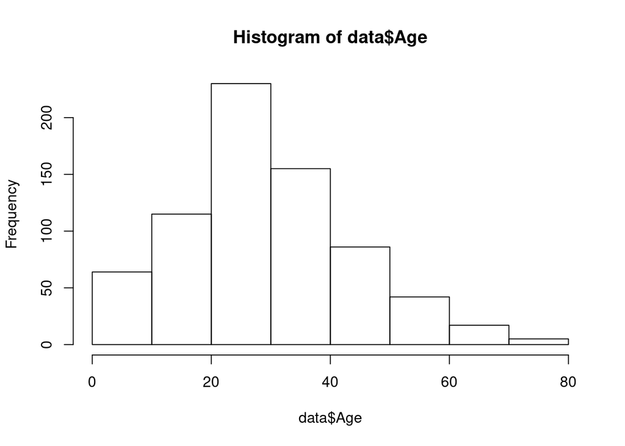

```r
hist(data$Age)
```

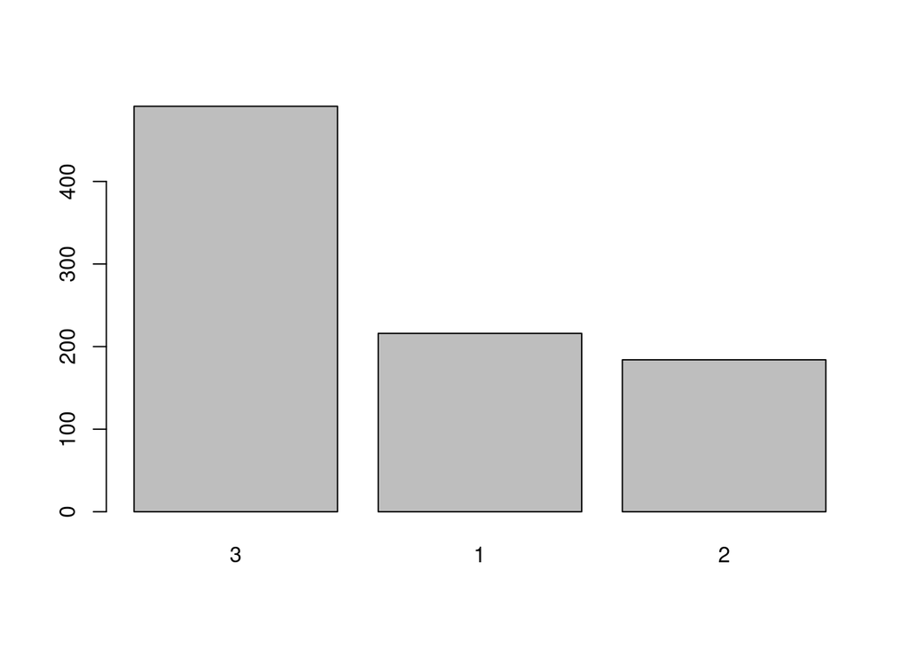

```r
barplot(sort(table(data$Pclass), decreasing = T))
```

Összetett kontingencia ábra

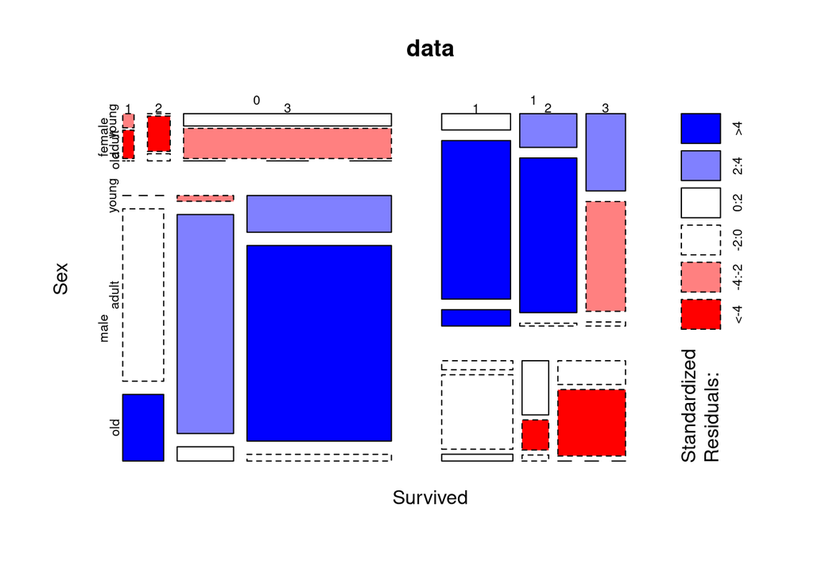

```r
data$Maturity <- cut(data$Age, breaks=c(0, 18, 55, 150), right = FALSE,
                     labels = c('young', 'adult', 'old'))
mosaicplot(Survived ~ Sex + Pclass + Maturity, data=data, shade=TRUE)
```

Korrelációs tábla

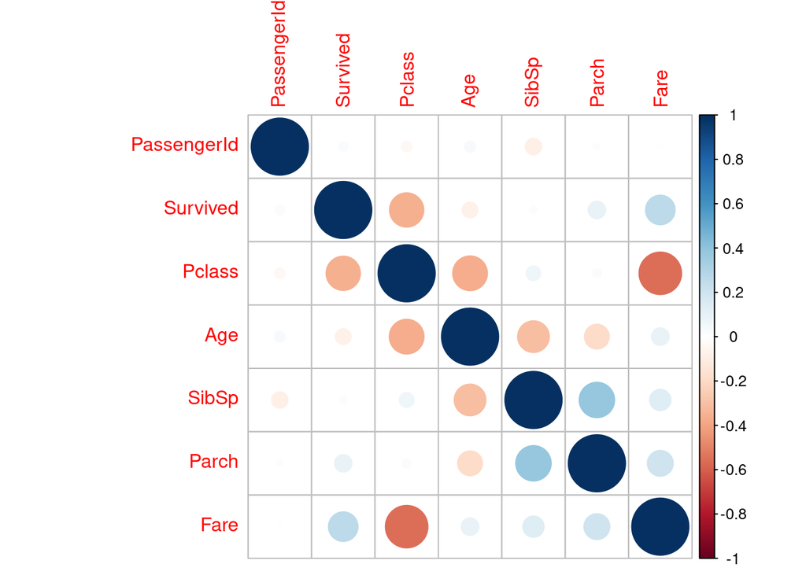

```r
cm = cor(data[,c("PassengerId","Survived","Pclass","Age","SibSp","Parch","Fare")], ,use="complete")
corrplot(cm)
```

# Korrespondencia analízis

## Korra vonatkozó hipotézis

Szignifikáns különbség van a túlélsben korosztály szerint:

```r
Tage <- table(data$Survived, data$Maturity)
Tage
```

```
##
##     young adult old
##   0    52   343  29
##   1    61   216  13
```

```r
chisq.test(Tage)
```

```
##
##  Pearson's Chi-squared test
##
## data:  Tage
## X-squared = 10.901, df = 2, p-value = 0.004294
```

## A nemre vonatkozó hipotézis

Hasonlóképpen a nemek között is:

```r
Tsex <- table(data$Survived, data$Sex)
Tsex
```

```
##
##     female male
##   0     81  468
##   1    233  109
```

```r
chisq.test(Tsex)
```

```
##
##  Pearson's Chi-squared test with Yates' continuity correction
##
## data:  Tsex
## X-squared = 260.72, df = 1, p-value < 2.2e-16
```

## Az osztályra vonatkozó hipotézis

És az osztályok között is:

```r
Tclass <- table(data$Survived, data$Pclass)
Tclass
```

```
##
##       1   2   3
##   0  80  97 372
##   1 136  87 119
```

```r
chisq.test(Tclass)
```

```
##
##  Pearson's Chi-squared test
##
## data:  Tclass
## X-squared = 102.89, df = 2, p-value < 2.2e-16
```

## Egyéb vizsgálat

Mi történik a hozzátartozók esetén? Később fontos lesz a döntési fáknál.

```r
Tparch <- table(data$Survived, data$Parch)
Tparch
```

```
##
##       0   1   2   3   4   5   6
##   0 445  53  40   2   4   4   1
##   1 233  65  40   3   0   1   0
```

```r
Tsibsp <- table(data$Survived, data$SibSp)
Tsibsp
```

```
##
##       0   1   2   3   4   5   8
##   0 398  97  15  12  15   5   7
##   1 210 112  13   4   3   0   0
```

# Rekurzív darabolás

Most nézzük meg, hogyan épülnek egymásra a fenti információk a döntési fa felépítésénél!

Ha minden változót beleveszünk, a modell érthető módon a neveket fogja felhasználni, 100%-os sikerességgel beazonosítva a tanuló adathalmzon: túltanulva garantáltan gyenge teljesítménnyel a teszt adathalmazon!

```r
Mhuge <- rpart(Survived ~ .,
               data=data,
               method='class',
               control = rpart.control(cp = 0, minbucket = 2, xval = 10))
printcp(Mhuge)
```

```
##
## Classification tree:
## rpart(formula = Survived ~ ., data = data, method = "class",
##     control = rpart.control(cp = 0, minbucket = 2, xval = 10))
##
## Variables actually used in tree construction:
## [1] Name
##
## Root node error: 342/891 = 0.38384
##
## n= 891
##
##   CP nsplit rel error  xerror     xstd
## 1  1      0         1 1.00000 0.042446
## 2  0      1         0 0.59649 0.036671
```

Nem elég azonban az sem, ha kizárjuk az egyedi azonosítokat (“PassengerId”, “Name”), mert így sem átülthethető jellemzőkre tanul rá:

```r
Mall <-  rpart(Survived ~ .,
               data=data[ , ! names(data) %in% c("PassengerId", "Name")],
               method='class',
               control = rpart.control(cp = 0, minbucket = 2, xval = 10))
printcp(Mall)
```

```
##
## Classification tree:
## rpart(formula = Survived ~ ., data = data[, !names(data) %in%
##     c("PassengerId", "Name")], method = "class", control = rpart.control(cp = 0,
##     minbucket = 2, xval = 10))
##
## Variables actually used in tree construction:
## [1] Age    Cabin  Sex    SibSp  Ticket
##
## Root node error: 342/891 = 0.38384
##
## n= 891
##
##          CP nsplit rel error  xerror     xstd
## 1 0.8479532      0  1.000000 1.00000 0.042446
## 2 0.0482456      1  0.152047 0.66082 0.037975
## 3 0.0146199      3  0.055556 0.67251 0.038194
## 4 0.0087719      4  0.040936 0.66667 0.038085
## 5 0.0058480      6  0.023392 0.66082 0.037975
## 6 0.0029240      7  0.017544 0.65497 0.037864
## 7 0.0014620      8  0.014620 0.64912 0.037751
## 8 0.0000000     10  0.011696 0.64912 0.037751
```

## Alapmodell

Vegyük tehát alapmodellnek a következőt: az “Age”, “Pclass” és “Age” alapján osztályozzunk!

```r
M <- rpart(Survived ~ Age + Sex + Pclass, data=data, method='class',
           control = rpart.control(cp = 0, minbucket = 2, xval = 10))
printcp(M)
```

```
##
## Classification tree:
## rpart(formula = Survived ~ Age + Sex + Pclass, data = data, method = "class",
##     control = rpart.control(cp = 0, minbucket = 2, xval = 10))
##
## Variables actually used in tree construction:
## [1] Age    Pclass Sex
##
## Root node error: 342/891 = 0.38384
##
## n= 891
##
##            CP nsplit rel error  xerror     xstd
## 1  0.44444444      0   1.00000 1.00000 0.042446
## 2  0.02339181      1   0.55556 0.55556 0.035750
## 3  0.01461988      2   0.53216 0.57018 0.036088
## 4  0.00584795      4   0.50292 0.54094 0.035402
## 5  0.00467836     12   0.44737 0.52339 0.034970
## 6  0.00389864     20   0.40351 0.51170 0.034675
## 7  0.00292398     23   0.39181 0.51462 0.034749
## 8  0.00146199     27   0.38012 0.51170 0.034675
## 9  0.00041771     31   0.37427 0.51462 0.034749
## 10 0.00000000     38   0.37135 0.51462 0.034749
```

Ez már ígéretes! Rajzoljuk ki:

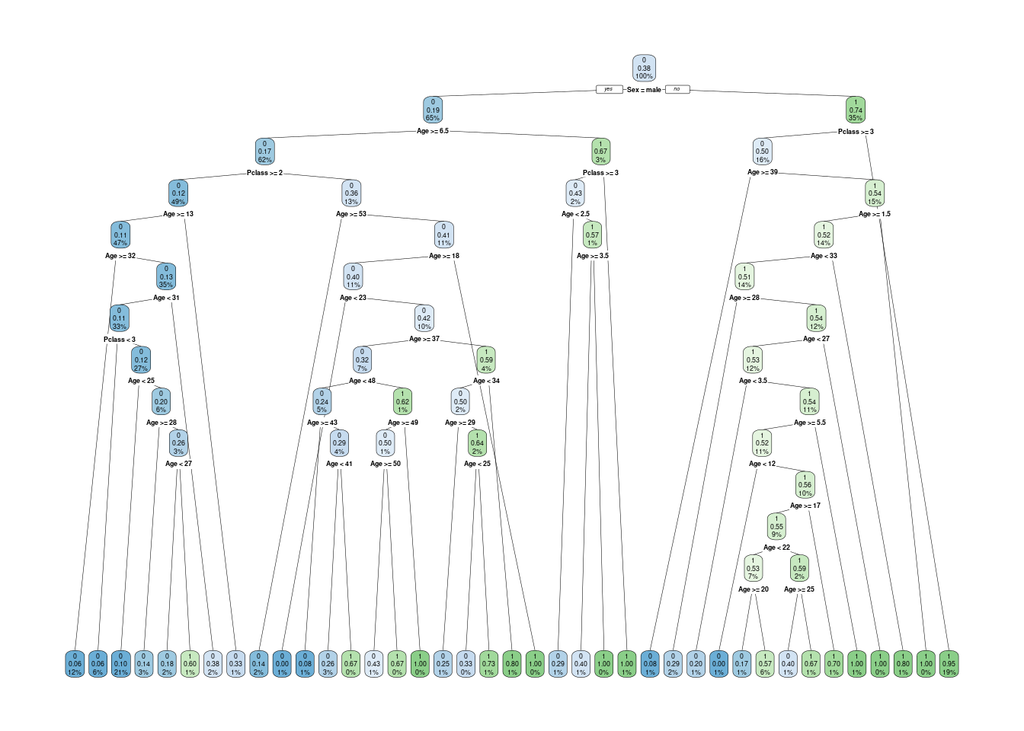

```r
#par(mar = c(0,0,0,0))
rpart.plot(M, branch = .1, compress = TRUE)
```

```r
#text(M)
```

A paraméterek:

```r
str(M$frame)
```

```
## 'data.frame':    77 obs. of  9 variables:
##  $ var       : Factor w/ 4 levels "<leaf>","Age",..: 4 2 3 2 2 1 2 3 1 2 ...
##  $ n         : int  891 577 553 433 421 105 316 295 52 243 ...
##  $ wt        : num  891 577 553 433 421 105 316 295 52 243 ...
##  $ dev       : num  342 109 93 50 46 6 40 32 3 29 ...
##  $ yval      : num  1 1 1 1 1 1 1 1 1 1 ...
##  $ complexity: num  0.444444 0.023392 0.004678 0.000418 0.000418 ...
##  $ ncompete  : int  2 1 1 1 1 0 1 1 0 0 ...
##  $ nsurrogate: int  0 0 0 0 0 0 0 0 0 0 ...
##  $ yval2     : num [1:77, 1:6] 1 1 1 1 1 1 1 1 1 1 ...
##   ..- attr(*, "dimnames")=List of 2
##   .. ..$ : NULL
##   .. ..$ : chr  "" "" "" "" ...
```

### A döntési fa elemzése

39 levél, 0-1-es ráírva, 891 adaton, az egyes leveleken a igazságkiértékelés:

```r
ind <- M$frame[,"var"]=="<leaf>"
sum(ind)
```

```
## [1] 39
```

```r
M$frame[ind,"n"]
```

```
##  [1] 105  52 187  29  22   5  21  12  22   5  12  31   3   7   3   3   8   3  11
## [20]  10   2   7   5   2  10  12  14   5   8   6  54   5  12  10   6   3   5   4
## [39] 170
```

```r
sum(M$frame[ind,"n"])
```

```
## [1] 891
```

```r
L <- attributes(M)$ylevels
L
```

```
## [1] "0" "1"
```

```r
L[M$frame[ind,"yval"]]
```

```
##  [1] "0" "0" "0" "0" "0" "1" "0" "0" "0" "0" "0" "0" "1" "0" "1" "1" "0" "0" "1"
## [20] "1" "1" "0" "0" "1" "1" "0" "0" "0" "0" "0" "1" "0" "1" "1" "1" "1" "1" "1"
## [39] "1"
```

```r
M$frame[ind,c("yval","n")]
```

|  | yval | n |
| --- | --- | --- |
| 32 | 1 | 105 |
| 132 | 1 | 52 |
| 266 | 1 | 187 |
| 534 | 1 | 29 |
| 1070 | 1 | 22 |
| 1071 | 2 | 5 |
| 67 | 1 | 21 |
| 17 | 1 | 12 |
| 18 | 1 | 22 |
| 76 | 1 | 5 |

[output cut: 29 more lines]

Az aggregátumok: 578 halott, 313 túlélő

```r
W <- aggregate(M$frame[ind,"n"],by=list(L[M$frame[ind,"yval"]]),FUN=sum)
w<-W[,2];names(w)<-W[,1]
w
```

```
##   0   1
## 578 313
```

### Predikciós mutatók

```r
C <- predict(M,type ="class")
table(C)
```

```
## C
##   0   1
## 578 313
```

A modell pontossága: 86%

```r
table(data$Survived,C)
```

```
##    C
##       0   1
##   0 500  49
##   1  78 264
```

```r
sum(diag(table(data$Survived,C)))/nrow(data)
```

```
## [1] 0.8574635
```

### Redukált alapmodell

A fa egyszerűsítése után a `Pclass` változó már nem szignifikáns:

```r
Mred <- prune(M, cp = 0.02)
Mred
```

```
## n= 891
##
## node), split, n, loss, yval, (yprob)
##       * denotes terminal node
##
## 1) root 891 342 0 (0.6161616 0.3838384)
##   2) Sex=male 577 109 0 (0.8110919 0.1889081)
##     4) Age>=6.5 553  93 0 (0.8318264 0.1681736) *
##     5) Age< 6.5 24   8 1 (0.3333333 0.6666667) *
##   3) Sex=female 314  81 1 (0.2579618 0.7420382) *
```

```r
printcp(Mred)
```

```
##
## Classification tree:
## rpart(formula = Survived ~ Age + Sex + Pclass, data = data, method = "class",
##     control = rpart.control(cp = 0, minbucket = 2, xval = 10))
##
## Variables actually used in tree construction:
## [1] Age Sex
##
## Root node error: 342/891 = 0.38384
##
## n= 891
##
##         CP nsplit rel error  xerror     xstd
## 1 0.444444      0   1.00000 1.00000 0.042446
## 2 0.023392      1   0.55556 0.55556 0.035750
## 3 0.020000      2   0.53216 0.57018 0.036088
```

A redukált fa:

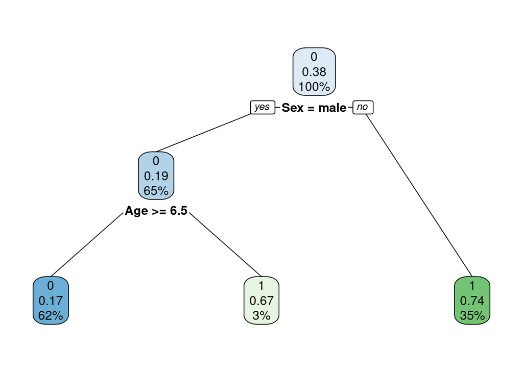

```r
#par(mar = c(0,0,0,0))
rpart.plot(Mred, branch = 0.3, compress = TRUE)
```

```r
#text(Mred,col="red")
```

Az igazságértékelés: 80%-os pontosság megmaradt

```r
Cred<-predict(Mred,type ="class")
table(data$Survived,Cred)
```

```
##    Cred
##       0   1
##   0 460  89
##   1  93 249
```

```r
sum(diag(table(data$Survived,Cred)))/nrow(data)
```

```
## [1] 0.7957351
```

A keletkezett hiba: 40 hibás halott, 15 hibás túlélő

```r
diag(table(data$Survived,C))-diag(table(data$Survived,Cred))
```

```
##  0  1
## 40 15
```